# Una herramienta clínica basada en el aprendizaje automático para diagnosticar la esclerosis múltiple mediante perfiles de expresión de microarrays de múltiples cohortes

### Una herramienta clínica basada en el aprendizaje automático para diagnosticar la esclerosis múltiple mediante perfiles de expresión de microarrays de múltiples cohortes.

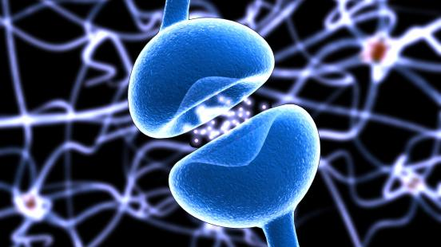

##### Amelia Martínez Sequera

##### Máster Bioinformática y Bioestadística

##### Área 4. Estadística y bioinformática

##### Consultor/a:Romina Rebrij

##### PRA: Antoni Pérez Navarro

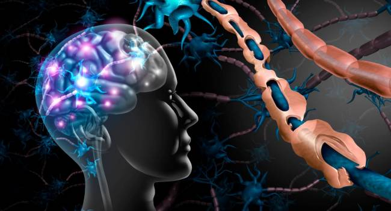

[figure not shown]

La prevalencia es mayor a medida que aumenta la distancia al ecuador

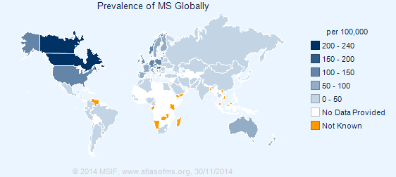

[figure not shown]

CIS: síndrome clínicamente aislado

[figure not shown]

## DIAGNÓSTICO MRI

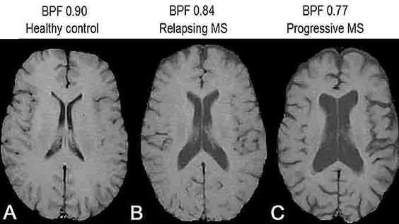

## MICROARRAYS DE CÉLULAS MONONUCLEARES DE SANGRE PERIFÉRICA

[figure not shown]

## OBJETIVO

Construir una herramienta clínica basada en el aprendizaje automático para predecir subtipos de esclerosis múltiple utilizando datos de expresión de microarrays de múltiples cohortes

**Se trata, por lo tanto, de un problema de clasificación multiclase supervisado.**

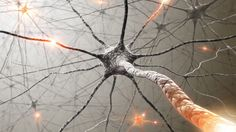

## METODOLOGÍA

1. Analizar la capacidad de distintos algoritmos de aprendizaje automático para encontrar patrones en los niveles que expresión genética que permitan clasificar distintos tipos de estadíos de esclerosis múltiple (EM) de forma correcta.
- REDES NEURONALES ARTIFICIALES
- MÁQUINAS DE VECTOR SOPORTE
- RANDOM FOREST

## METODOLOGÍA

2. Determinar si existe algún método de aprendizaje automático capaz de predecir, con un porcentaje de acierto alto, el tipo de esclerosis múltiple en función sus niveles de expresión.
- ERROR DE VALIDACIÓN
- ERROR DE TEST

## METODOLOGÍA

3. Determinar, entre los varios miles de genes disponibles, si son todos importantes en vista a la clasificación o son solo unos pocos los que aportan información relevante.
- FILTRADO POR ANOVA P VALUE
- FILTRADO POR SIGNAL TO NOISE
- REDUCCIÓN POR ANÁLISIS DE COMPONENTES PRINCIPALES.

## CONJUNTO DE DATOS

242 muestras, 4 clases:

Remitente recurrente: 121

Síndrome clínico aislado: 60

Progresiva primaria: 35

Progresiva secundaria: 26

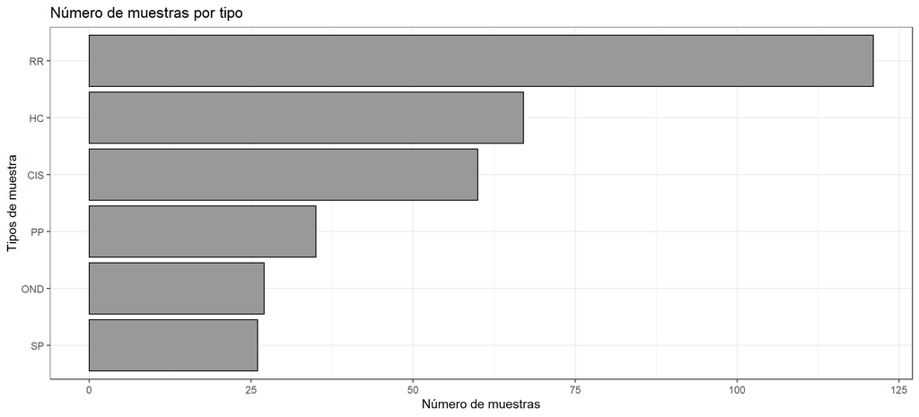

## División de los datos en conjunto de entrenamiento 80% y conjunto de test 20%

| train.Var1 | train.Freq | test.Var1 | test.Freq |
| --- | --- | --- | --- |
| CIS | 0.265 | CIS | 0.273 |
| PP | 0.143 | PP | 0.091 |
| RR | 0.490 | RR | 0.545 |
| SP | 0.102 | SP | 0.091 |

Porcentaje aproximado de aciertos que se espera si siempre se predice “RR” Porcentaje de aciertos (accuracy) que deben ser capaces de superar los modelos predictivos para considerarse mínimamente útiles RR 49%

## PREPROCESADO DE LOS DATOS

10160 genes

- Se eliminan genes con varianza próxima a 0
- ESTANDARIZACIÓN: Centrado y Normalización

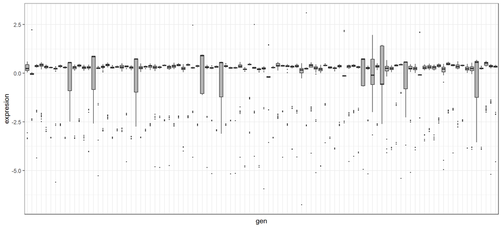

## SELECCIÓNN DE GENES Y REDUCCIÓN DE DIMENSIONALIDAD

ANOVA P VALUE

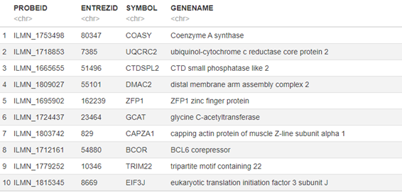

VERSIÓN PARALELIZADA DE BOOTSTRAPPING PARA FILTRADO POR ANOVA.

Se filtran los 100, 50 y 25 genes identificados como más relevantes mediante anova

## SIGNAL TO NOISE S2N

S2N=$\frac{μ_{grupo i} − μ_{resto de grupos}}{σ_{grupo i} + σ_{resto de grupos}}$

VERSIÓN PARALELIZADA DE BOOTSTRAPPING PARA FILTRADO POR S2N.

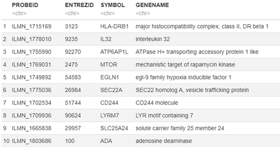

## ANÁLISIS DE COMPONENTES PRINCIPALES

Se aplica un PCA a los niveles de expresión y se conservan las componentes principales hasta alcanzar un 95% de varianza explicada.

## Diagrama de los modelos ajustados y los genes empleados

[interactive chart not shown]

## SUPPORT VECTOR MACHINES

- sigma: coeficiente del kernel radial.
- C: penalización por violaciones del margen del hiperplano.

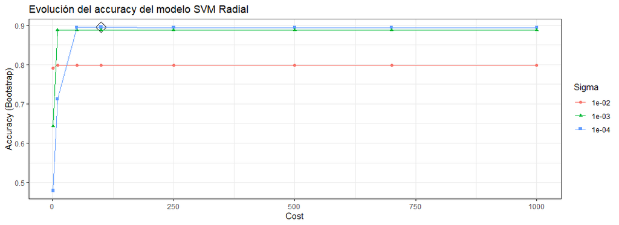

Mejor modelo: filtrado p value 100.  
sigma = 1e-04, C = 100, Accuracy = 0.8950512

## RANDOM FOREST

- mtry: número predictores seleccionados aleatoriamente en cada árbol.
- min.node.size: tamaño mínimo que tiene que tener un nodo para poder ser dividido.
- splitrule: criterio de división.

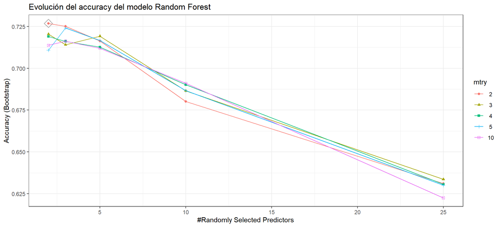

Mejor modelo: filtrado p value 25  
mtry = 2, Min.node.size = 2, Accuracy = 0.7268851

## RED NEURONAL ARTIFICIAL

- 1 capa oculta
- size: número de neuronas en la capa oculta.
- decay: controla la regularización durante el entrenamiento de la red.

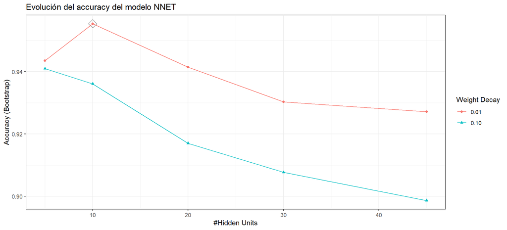

Mejor modelo: filtrado p value 100  
size = 10, decay = 0.01, Accuracy = 0.9554087

## RED NEURONAL ARTIFICIAL

- 1 capa oculta
- size: número de neuronas en la capa oculta.
- decay: controla la regularización durante el entrenamiento de la red.

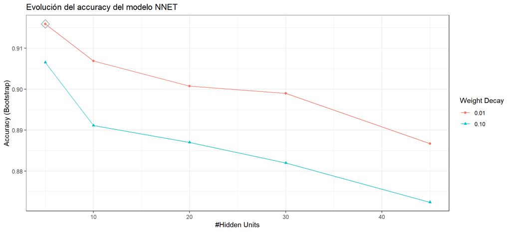

Mejor modelo: filtrado p value 50  
size = 5, decay = 0.01, Accuracy = 0.9159172

## ERROR DE VALIDACIÓN

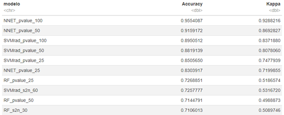

[figure not shown]

## ERROR DE VALIDACIÓN

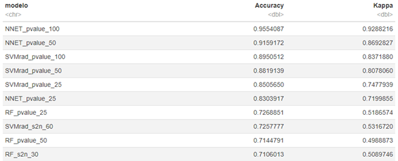

[figure not shown]

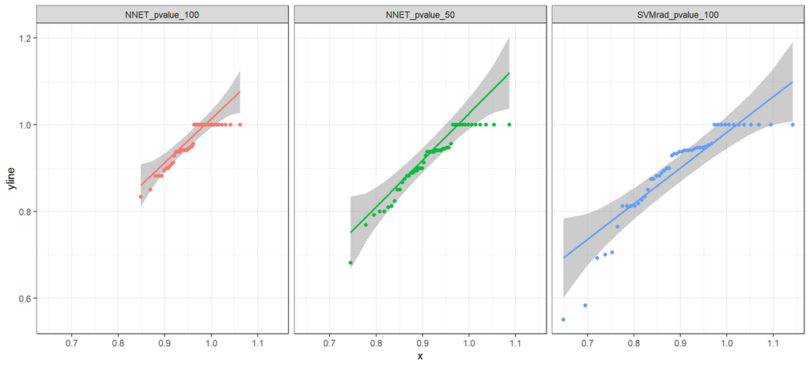

**Según el proceso de validación por bootstraping, el mejor modelo es Redes neuronales artificiales con filtrado pvalue 100**

## ERROR DE TEST

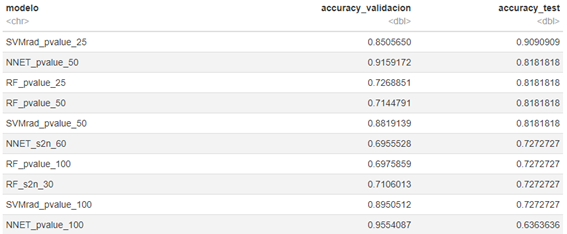

[figure not shown]

Es muy específico para la clase CIS, y muy sensible para la clase RR. No es buen predictor para las clases SP y PP.

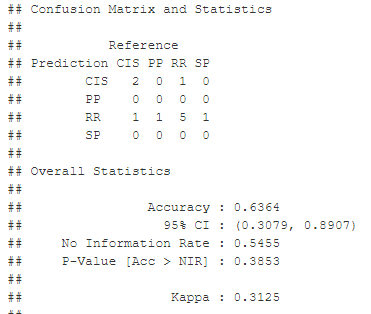

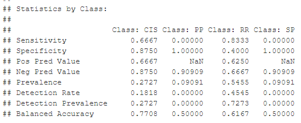

No es buen predictor de las clases PP y SP.

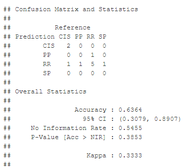

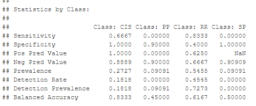

## CONCLUSIONES

- No expresión diferencial de PP y SP
- Alta dimensionalidad de los microarrays
- Desequilibrio de clases : resampling
- Elección del filtrado
- Bootstrapping

## LINEAS DE FUTURO

- Diagnóstico precoz y específico de cada fase
- Identificación de genes

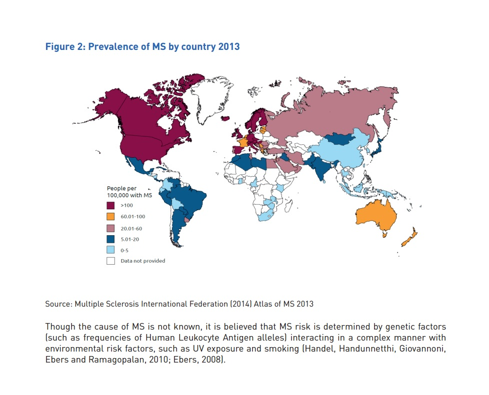